# Prak4

Siti Zahra Muthmainnah

2026-09-19

## MA(2)

theta_1 = 0.4, theta_2 = 0.6, n = 300 ### Pembangkitan Model

```r
#Manual
set.seed(2048)
wn <- rnorm(300)
ma = numeric(300)
ma[1] = wn[1]
ma[2] = wn[2] + 0.4*wn[1]
for(i in 3:300) ma[i] = wn[i] + 0.4*wn[i-1] + 0.6*wn[i-2]
#ma

#Fungsi arima.sim()
ma_sim = arima.sim(list(order = c(0, 0, 2), ma = c(0.4, 0.6)), n = 300)
```

### Plot

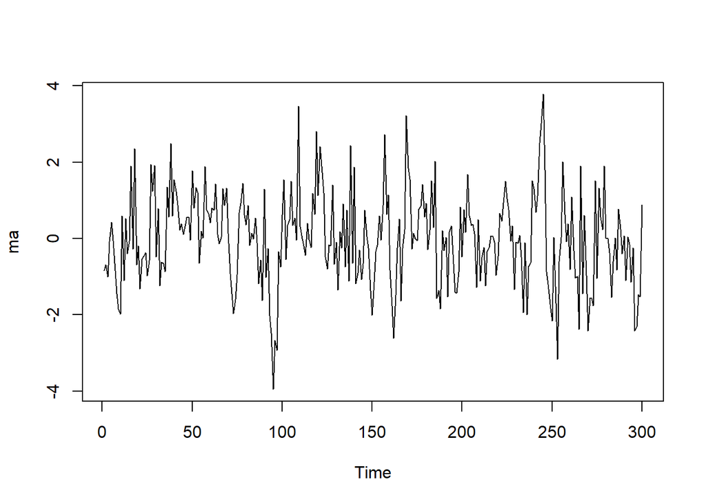

```r
#Plot Time Series
ts.plot(ma)
```

Data stasioner karena tidak membentuk tren

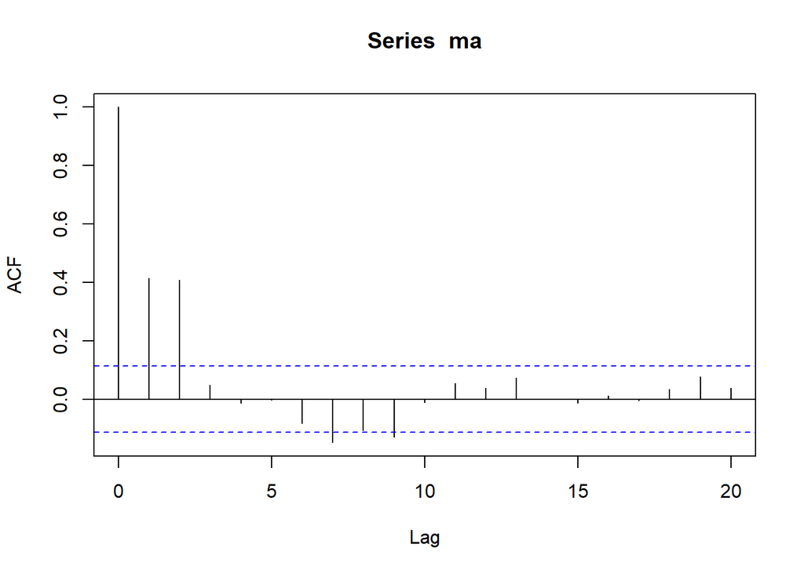

```r
#Plot ACF
acf(ma, lag.max = 20)
```

ACF cuts off di lag ke-2.

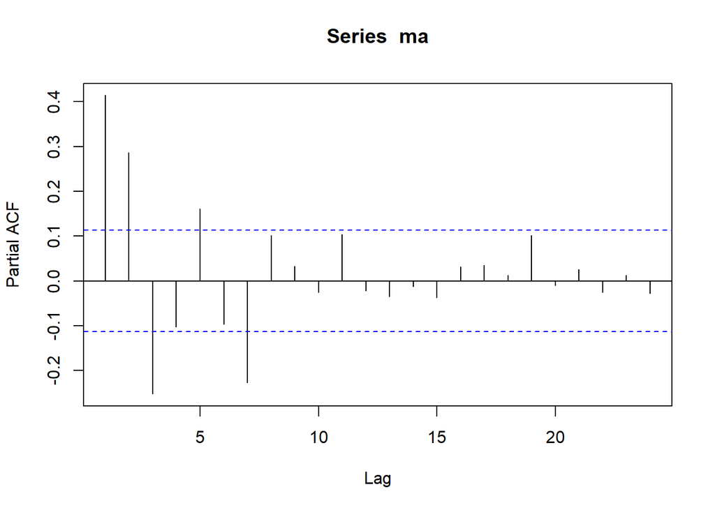

```r
#Plot PACF
pacf(ma)
```

PACF cenderung tails off dan membentuk gelombang sinus.

```r
#Plot EACF
TSA::eacf(ma)
```

```
## AR/MA
##   0 1 2 3 4 5 6 7 8 9 10 11 12 13
## 0 x x o o o o x o x o o  o  o  o
## 1 x x x o o o o o x o o  o  o  o
## 2 x x o o o o x o x o o  o  o  o
## 3 x x o o o o o o x o o  o  o  o
## 4 x x x x o x o o o o o  o  o  o
## 5 x x x x x x x o o o o  o  o  o
## 6 x x x o x x x o o o o  o  o  o
## 7 x x o x o o x o o o o  o  o  o
```

Segitiga nol berada pada ordo AR(0) dan MA(2)

Kesimpulan: data stasioner.

### Scatter Plot Antarlag

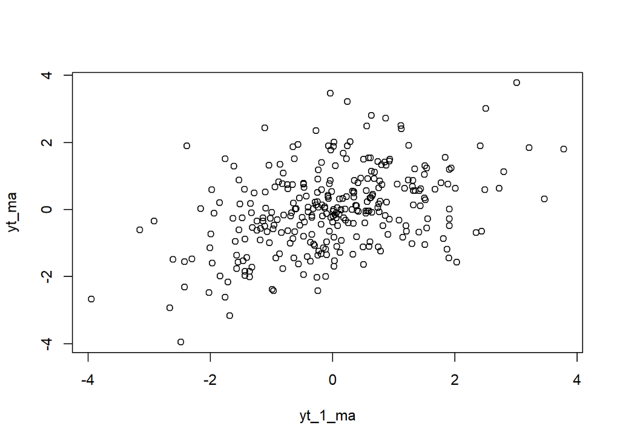

```r
#Y_t thd Y_{t-1}
yt_ma = ma[-1]
yt_1_ma = ma[-300]
plot(y = yt_ma, x=yt_1_ma)
```

```r
cor(yt_ma,yt_1_ma)
```

```
## [1] 0.4149308
```

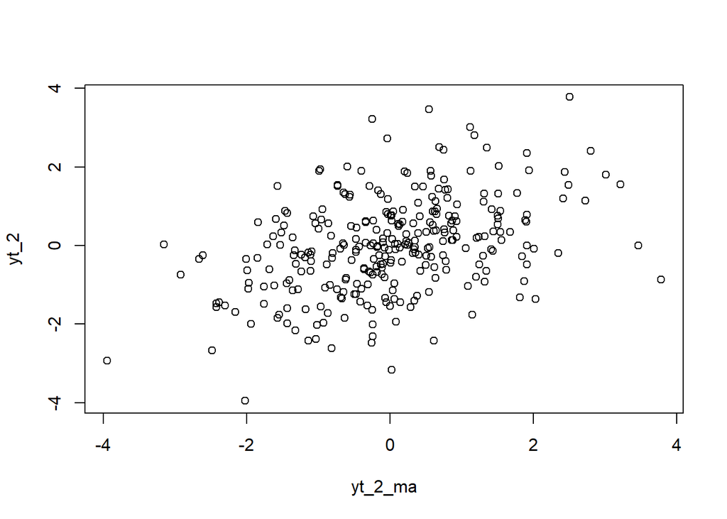

```r
#Y_t thd Y_{t-2}
yt_2 = ma[-c(1,2)]
yt_2_ma = ma[-c(299, 300)]
plot(y=yt_2, x = yt_2_ma)
```

```r
cor(yt_2,yt_2_ma)
```

```
## [1] 0.4113084
```

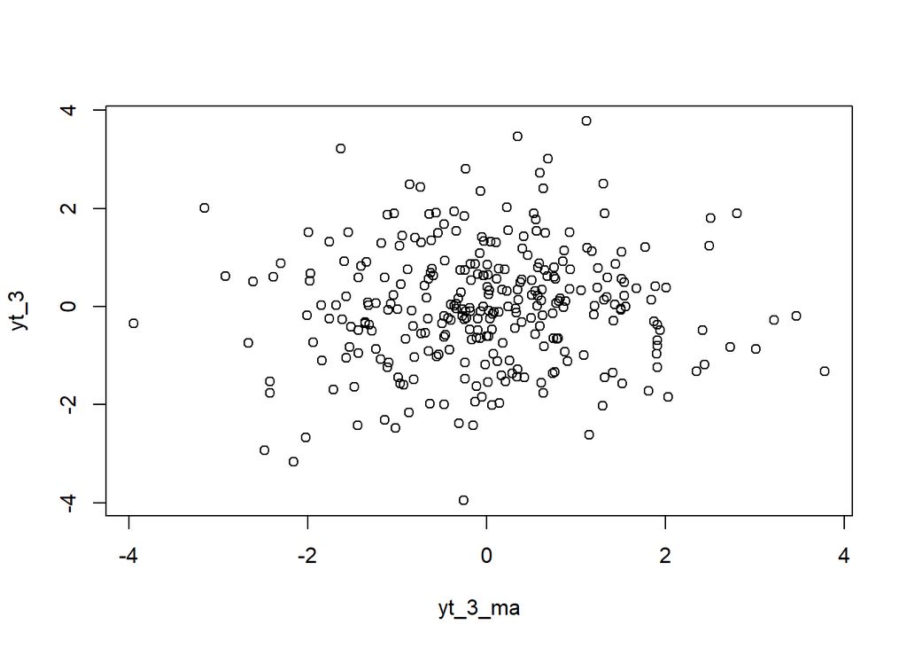

```r
#Y_t thd Y_{t-3}
yt_3 = ma[-c(1, 2, 3)]
yt_3_ma = ma[-c(300, 299, 298)]
plot(y = yt_3, x = yt_3_ma)
```

```r
cor(yt_3,yt_3_ma)
```

```
## [1] 0.04826397
```

### Korelasi Teoretis dan Data

```r
var_teoritis <- 1 + (0.4)^2 + (0.6)^2

# Autokovarians
gamma_1 <- (0.4 + 0.4 * 0.6) # 0.4 + 0.24 = 0.64
gamma_2 <- 0.6                      # 0.6

# Autokorelasi Teoritis (rho_k = gamma_k / gamma_0)
rho_teoritis <- c(
  rho_1 = gamma_1 / var_teoritis, # 0.64 / 1.52 ≈ 0.42105
  rho_2 = gamma_2 / var_teoritis, # 0.60 / 1.52 ≈ 0.39474
  rho_3 = 0                       # Untuk k >= 3, rho_k = 0
)

acf_calc <- acf(ma, lag.max = 3, plot = FALSE)
rho_sampel <- acf_calc$acf[2:4] # Ambil lag 1, 2, dan 3

# Menampilkan Hasil Perbandingan
tabel_korelasi <- data.frame(
  Lag = 1:3,
  Teoritis = round(rho_teoritis, 5),
  Sampel_Bangkitan = round(as.vector(rho_sampel), 5)
)
print(tabel_korelasi)
```

```
##       Lag Teoritis Sampel_Bangkitan
## rho_1   1  0.42105          0.41421
## rho_2   2  0.39474          0.40929
## rho_3   3  0.00000          0.04789
```

Nilai korelasi teoretis dengan sampel bangkitan mirip.

## AR(2)

```r
phi1 = 0.5
phi2 = 0.2
n = 300
#Manual
set.seed(2048)
ar = numeric(n)
ar[1] = wn[1]
ar[2] = phi1*ar[1] + wn[2]
for(i in 3:n) ar[i] = wn[i] + phi1*ar[i-1] + phi2*ar[i-2]
#ar

#Fungsi arima.sim()
ar_sim = arima.sim(list(order = c(2, 0, 0), ar = c(phi1, phi2)), n = 300)
```

### Plot

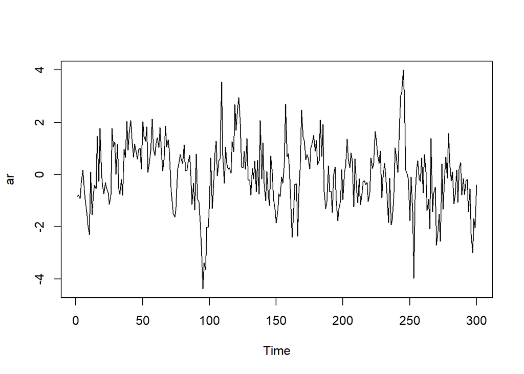

```r
#Plot Time Series
ts.plot(ar)
```

Stasioner karena tidak membentuk tren tertentu.

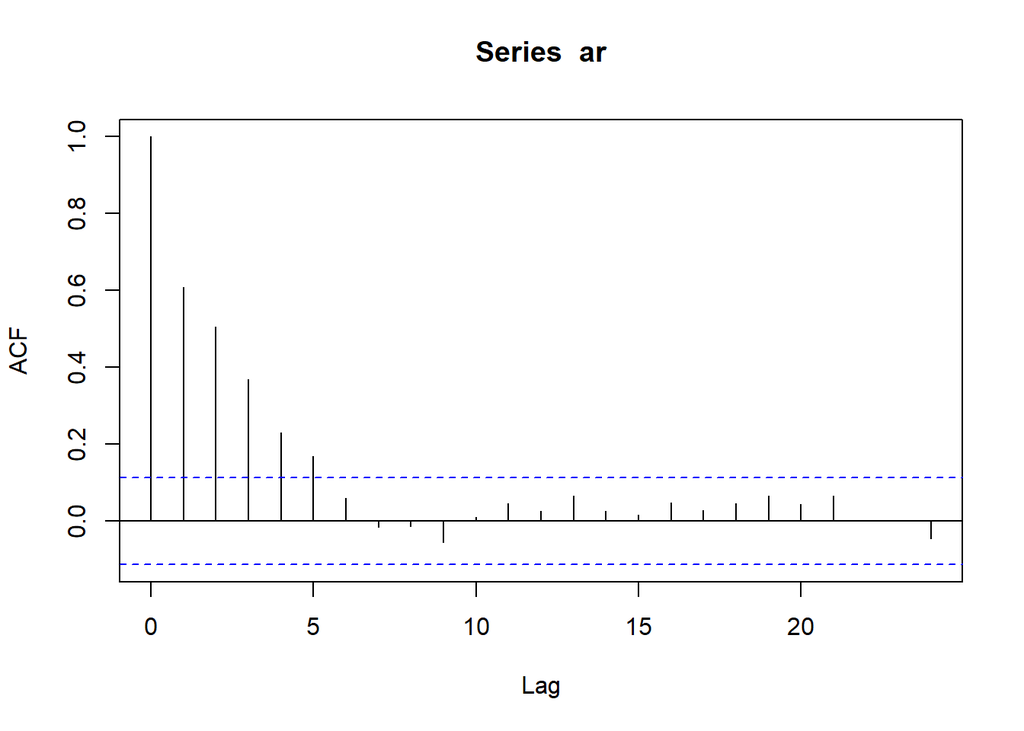

```r
#Plot ACF
acf(ar)
```

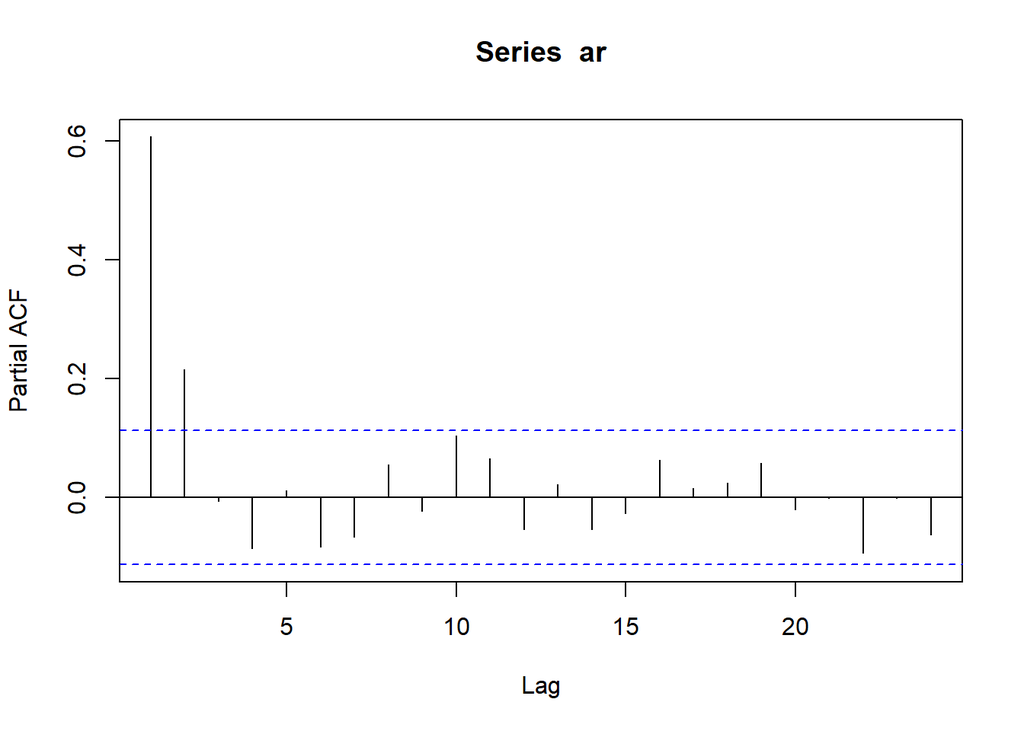

```r
#Plot PACF
pacf(ar)
```

Cutoff di lag 2

```r
#Plot EACF
TSA::eacf(ar)
```

```
## AR/MA
##   0 1 2 3 4 5 6 7 8 9 10 11 12 13
## 0 x x x x x o o o o o o  o  o  o
## 1 x o o o x o o o o o o  o  o  o
## 2 o x x o x o o o o o o  o  o  o
## 3 o x x o x o o o o o o  o  o  o
## 4 x x o x o o o o o o o  o  o  o
## 5 x x x x o o o o o o o  o  o  o
## 6 x x x x x o o o o o o  o  o  o
## 7 x x x x x o o o o o o  o  o  o
```

### Scatter Plot Antarlag

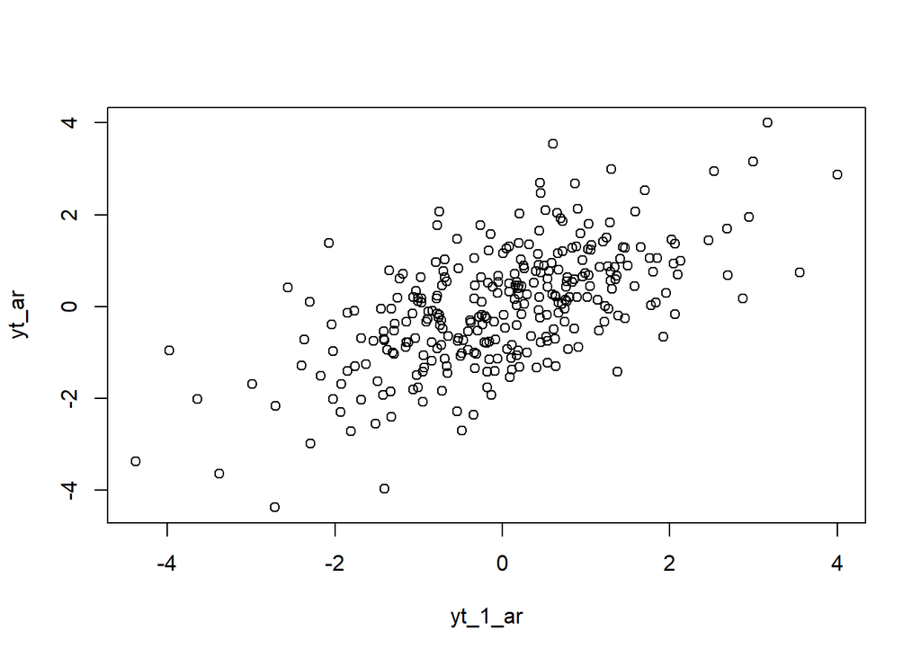

```r
#Y_t thd Y_{t-1}
yt_ar = ar[-1]
yt_1_ar = ar[-300]
plot(y = yt_ar, x=yt_1_ar)
```

```r
cor(yt_ar,yt_1_ar)
```

```
## [1] 0.6082075
```

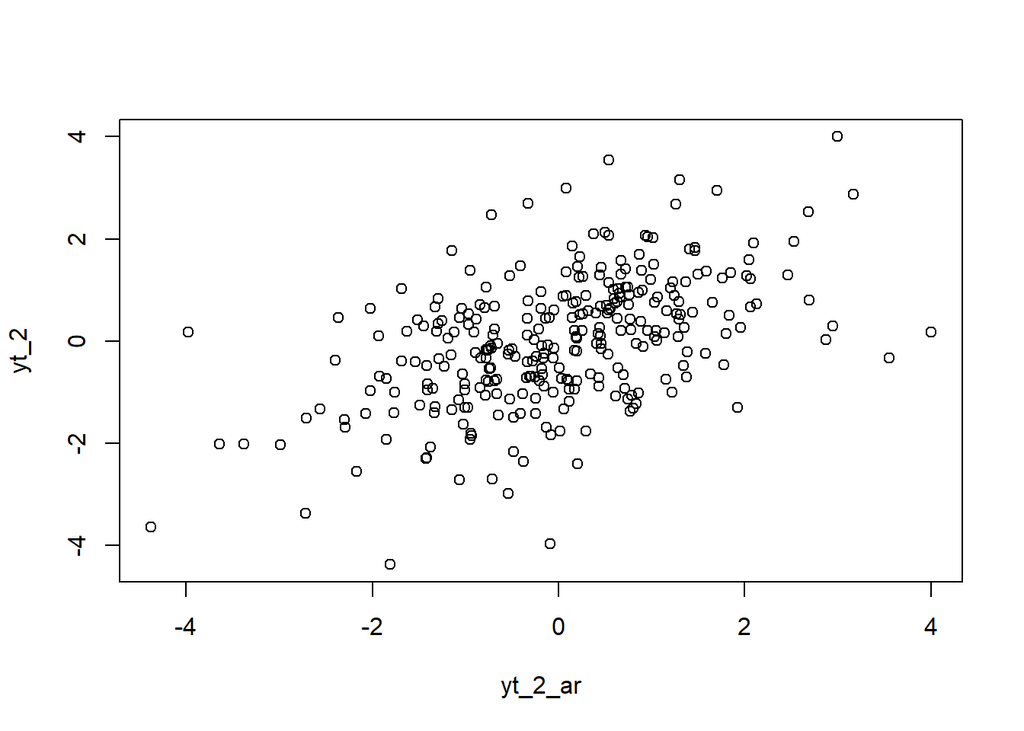

```r
#Y_t thd Y_{t-2}
yt_2 = ar[-c(1,2)]
yt_2_ar = ar[-c(299, 300)]
plot(y=yt_2, x = yt_2_ar)
```

```r
cor(yt_2,yt_2_ar)
```

```
## [1] 0.5085671
```

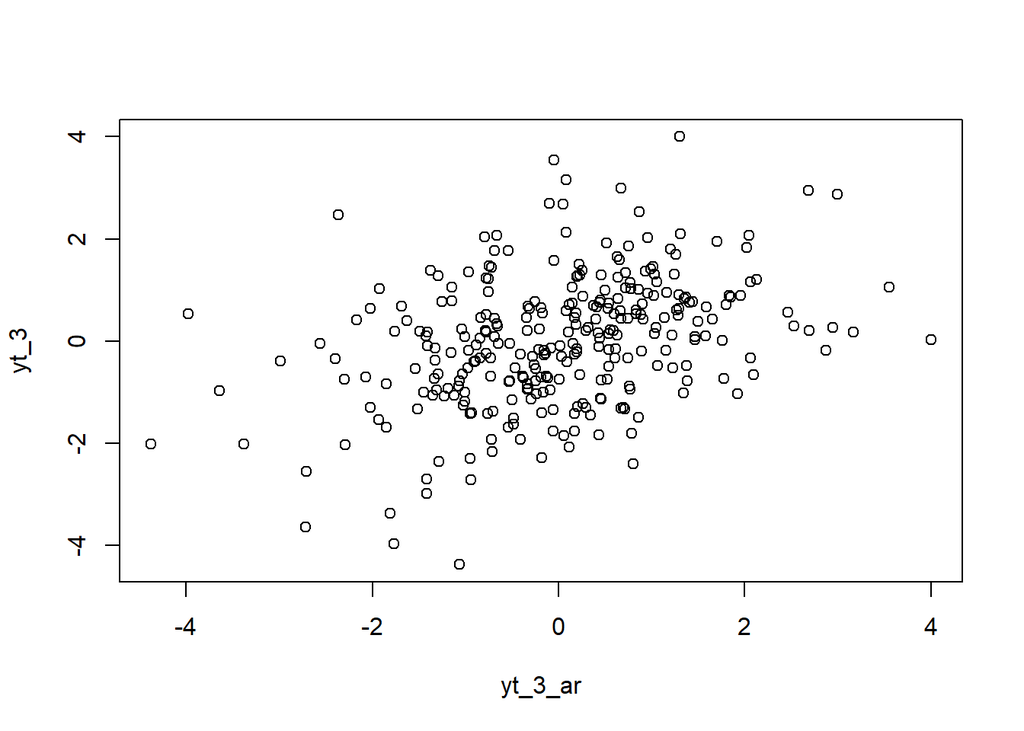

```r
#Y_t thd Y_{t-3}
yt_3 = ar[-c(1,2,3)]
yt_3_ar = ar[-c(298, 299, 300)]
plot(y=yt_3, x = yt_3_ar)
```

```r
cor(yt_3,yt_3_ar)
```

```
## [1] 0.3714899
```

```r
rho_teoritis_manual <- numeric(3)

# Base Case Yule-Walker
rho_teoritis_manual[1] <- phi1 / (1 - phi2)                  # Lag 1: 0.5 / 0.8 = 0.625
rho_teoritis_manual[2] <- phi1 * rho_teoritis_manual[1] + phi2 # Lag 2: (0.5 * 0.625) + 0.2 = 0.5125
rho_teoritis_manual[3] <- phi1 * rho_teoritis_manual[2] + phi2 * rho_teoritis_manual[1] # Lag 3: (0.5 * 0.5125) + (0.2 * 0.625) = 0.38125

names(rho_teoritis_manual) <- c("Lag 1", "Lag 2", "Lag 3")


rho_sampel <- c(0.6082075, 0.5086710, 0.3714899)

tabel_evaluasi <- data.frame(
  Lag = 1:3,
  Teoritis_YuleWalker = round(rho_teoritis_manual, 5),
  Hasil_Simulasi = round(rho_sampel, 5)
)

print(tabel_evaluasi)
```

[output not shown]

Nilai korelasi teoretis dengan sampel bangkitan mirip.

## ARMA(2, 2)

### Pembangkitan Model

```r
set.seed(2048)
n <- 300

phi1 <- 0.5
phi2 <- 0.2
theta1 <- 0.4
theta2 <- 0.6

wn <- rnorm(n, mean = 0, sd = 1)

arma <- numeric(n)
arma[1] <- wn[1]

arma[2] <- (phi1 * arma[1]) + wn[2] + (theta1 * wn[1])

for (i in 3:n)
  arma[i] <- (phi1 * arma[i-1]) + (phi2 * arma[i-2]) + wn[i] + (theta1 * wn[i-1]) + (theta2 * wn[i-2])
#arma

# ==============================================================================
# 2. Pembangkitan Otomatis (arima.sim)
# ==============================================================================
# Di arima.sim, order = c(p, d, q) -> ARMA(2,0,2) alias order = c(2, 0, 2)
# Parameter 'ar' diisi vector c(phi1, phi2)
# Parameter 'ma' diisi vector c(theta1, theta2)

arma_sim <- arima.sim(
  model = list(
    order = c(2, 0, 2),
    ar = c(phi1, phi2),
    ma = c(theta1, theta2)
  ),
  n = n
)
#arma_sim
```

### Plot

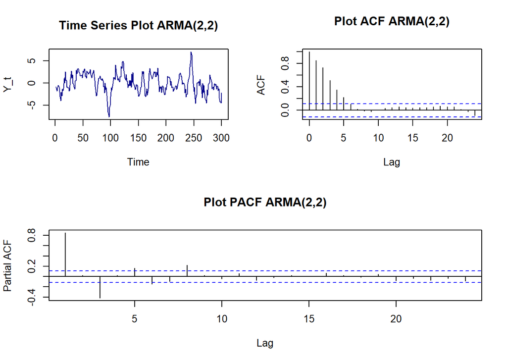

```r
layout(matrix(c(1, 2,
                3, 3), nrow = 2, byrow = TRUE))
plot.ts(arma, main = "Time Series Plot ARMA(2,2)", ylab = "Y_t", col = "darkblue")
acf(arma, main = "Plot ACF ARMA(2,2)")
pacf(arma, main = "Plot PACF ARMA(2,2)")
```

```r
par(mfrow = c(1, 1))
TSA::eacf(arma)
```

```
## AR/MA
##   0 1 2 3 4 5 6 7 8 9 10 11 12 13
## 0 x x x x x o o o o o o  o  o  o
## 1 o x o o x o o o o o o  o  o  o
## 2 o x x o o o o o o o o  o  o  o
## 3 o x x o o o o o o o o  o  o  o
## 4 o x x x o o o o o o x  o  o  o
## 5 x x o o o x o o o o o  o  o  o
## 6 x x x o x x o o o o o  o  o  o
## 7 x x o x x x o o o o o  o  o  o
```

Stasioner, tail off, ARMa(2, 3). Sesuai teori, tapi MA agak bergeser. Mungkin karena n tidak terlalu besar dan nilai theta yang cukup besar.

### Scatter Plot

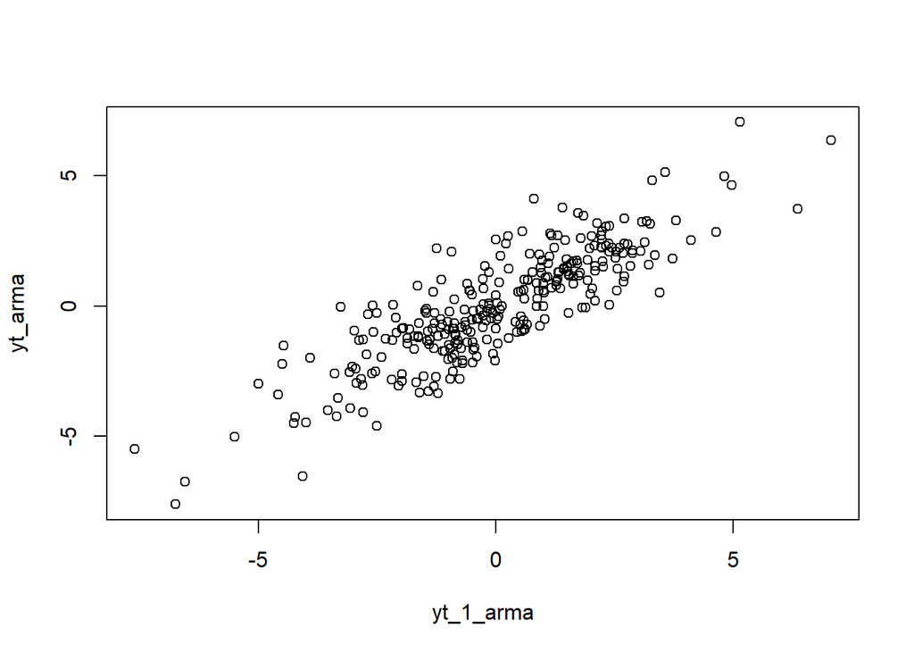

```r
#Y_t thd Y_{t-1}
yt_arma = arma[-1]
yt_1_arma = arma[-300]
plot(y = yt_arma, x=yt_1_arma)
```

```r
cor(yt_arma,yt_1_arma)
```

```
## [1] 0.8517739
```

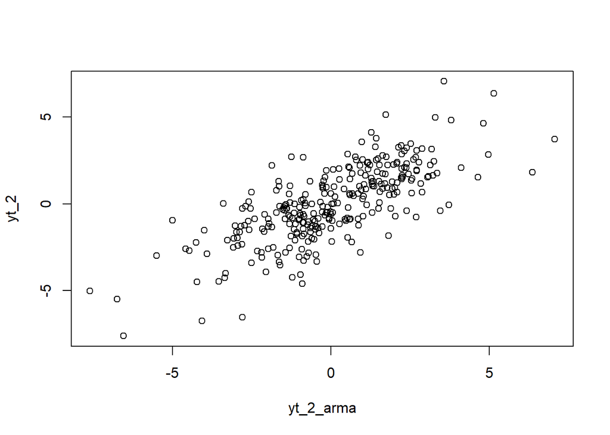

```r
#Y_t thd Y_{t-2}
yt_2 = arma[-c(1, 2)]
yt_2_arma = arma[-c(300, 299)]
plot(y = yt_2, x=yt_2_arma)
```

```r
cor(yt_2, yt_2_arma)
```

```
## [1] 0.7371772
```

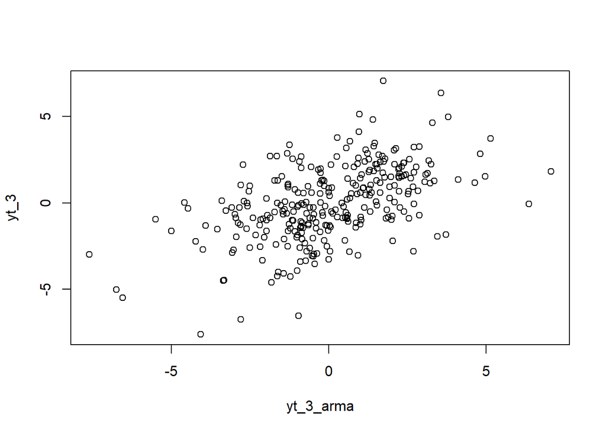

```r
#Y_t thd Y_{t-3}
yt_3 = arma[-c(1,2,3)]
yt_3_arma = arma[-c(298, 299, 300)]
plot(y=yt_3, x = yt_3_arma)
```

```r
cor(yt_3,yt_3_arma)
```

```
## [1] 0.5200621
```

Nilai korelasinya jatuh jauh di Y_t thd Y_{t-3}. Sesuai teori.

### Korelasi Teoretis dan Data

```r
yt <- arma

# Lag 1
rho_sampel_1 <- cor(yt[-1], yt[-n])

# Lag 2
rho_sampel_2 <- cor(yt[-c(1, 2)], yt[-c(n-1, n)])

# Lag 3
rho_sampel_3 <- cor(yt[-c(1, 2, 3)], yt[-c(n-2, n-1, n)])
rho_sampel <- c(rho_sampel_1, rho_sampel_2, rho_sampel_3)


rho_teoritis <- ARMAacf(ar = c(phi1, phi2), ma = c(theta1, theta2), lag.max = 3)[2:4]

tabel_hasil <- data.frame(
  Lag = paste("Lag", 1:3),
  Teoritis = round(as.numeric(rho_teoritis), 5),
  Sampel   = round(rho_sampel, 5)
)

print(tabel_hasil)
```

```
##     Lag Teoritis  Sampel
## 1 Lag 1  0.85920 0.85177
## 2 Lag 2  0.74919 0.73718
## 3 Lag 3  0.54644 0.52006
```

Korelasi teoretis dan sampel sangat mirip.